# PCA analytics

```r
#install.packages("factoextra")
rm(list=ls())
```

**New York Times opinion column:** https://www.nytimes.com/2020/09/09/opinion/united-states-social-progress.html

**Social Progress Imperative** https://www.socialprogress.org/

Quoting from their report:The Social Progress Index is a well-established measure, published since 2013, that is meant to catalyze improvement and drive action by presenting social outcome data in a useful and reliable way. Composed of multiple dimensions, the Social Progress Index can be used to benchmark success and provide a holistic, transparent, outcome-based measure of a country’s well-being that is independent of economic indicators. Policymakers, businesses, and countries’ citizens alike can use it to compare their country against others on different facets of social progress, allowing the identification of specific areas of strength or weakness.

We look at the most recent social progress data from 2011-2020 made available last week (10th September, 2020). Among the 192 countries listed in 2020, 163 are ranked according to Social Progress Index. We will consider this data set for our study.

**Goal:** How would we fair in creating an index of such nature if we did not have the Social Progress Index at hand.

|  | SPI.Rank | Country | SPI.country.code | SPI.year | Status | Social.Progress.Index | Basic.Human.Needs | Foundations.of.Wellbeing | Opportunity | Nutrition.and.Basic.Medical.Care | Water.and.Sanitation | Shelter | Personal.Safety | Access.to.Basic.Knowledge | Access.to.Information.and.Communications | Health.and.Wellness | Environmental.Quality | Personal.Rights | Personal.Freedom.and.Choice | Inclusiveness | Access.to.Advanced.Education | Undernourishment....of.pop.. | Deaths.from.infectious.diseases..deaths.100.000. | Child.stunting....of.children. | Maternal.mortality.rate..deaths.100.000.live.births. | Child.mortality.rate..deaths.1.000.live.births. | Unsafe.water..sanitation.and.hygiene.attributable.deaths..per.100.000.pop.. | Populations.using.unsafe.or.unimproved.water.sources.... | Populations.using.unsafe.or.unimproved.sanitation.... | … |
| --- | --- | --- | --- | --- | --- | --- | --- | --- | --- | --- | --- | --- | --- | --- | --- | --- | --- | --- | --- | --- | --- | --- | --- | --- | --- | --- | --- | --- | --- | --- |
| 1 | NA | World | WWW | 2020 |  | 64.24 | 74.65 | 60.82 | 57.25 | 84.63 | 74.72 | 77.09 | 62.15 | 75.18 | 70.33 | 60.88 | 36.87 | 60.09 | 63.24 | 39.25 | 66.42 | 9.097 | 134.0231 | 21.8804 | 99.3684 | 27.9923 | 29.6395 | 33.0701 | 28.3599 | … |
| 2 | 155 | Afghanistan | AFG | 2020 | Ranked | 42.29 | 52.90 | 39.50 | 34.47 | 61.51 | 49.45 | 56.63 | 44.02 | 30.55 | 41.07 | 34.47 | 51.93 | 40.88 | 39.82 | 30.11 | 27.05 | 29.900 | 154.9591 | 48.7340 | 289.4140 | 62.2764 | 16.2000 | 82.5060 | 69.7940 | … |
| 3 | 54 | Albania | ALB | 2020 | Ranked | 75.41 | 86.92 | 82.71 | 56.60 | 92.99 | 90.61 | 90.54 | 73.55 | 92.32 | 77.32 | 74.47 | 86.71 | 82.06 | 47.09 | 42.50 | 54.75 | 3.600 | 15.8144 | 20.8190 | 9.5290 | 8.8233 | 0.2730 | 17.5560 | 12.5090 | … |
| 4 | 83 | Algeria | DZA | 2020 | Ranked | 69.92 | 87.69 | 66.05 | 56.02 | 92.24 | 93.81 | 93.51 | 71.21 | 81.00 | 51.41 | 68.13 | 63.63 | 50.32 | 69.00 | 45.01 | 59.75 | 2.800 | 22.5509 | 12.5440 | 61.1770 | 23.4821 | 1.0280 | 11.6410 | 7.5800 | … |
| 5 | 151 | Angola | AGO | 2020 | Ranked | 48.16 | 52.60 | 52.20 | 39.69 | 64.94 | 37.69 | 57.31 | 50.46 | 57.07 | 37.50 | 44.64 | 69.58 | 58.24 | 42.43 | 30.96 | 27.13 | 18.600 | 418.9029 | 41.0410 | 183.2540 | 77.1645 | 101.6260 | 76.6250 | 54.5420 | … |
| 6 | 41 | Argentina | ARG | 2020 | Ranked | 80.66 | 87.73 | 80.05 | 74.20 | 94.33 | 95.79 | 95.49 | 65.33 | 88.50 | 85.67 | 69.55 | 76.50 | 88.36 | 69.77 | 63.14 | 75.53 | 3.800 | 67.3925 | 7.4400 | 49.2320 | 9.9450 | 1.4660 | 7.8120 | 4.7280 | … |

Note that there is a ranking of the countries and a social progress index mentioned here.

#### Data processing

We select the relevant parts for use. First we take the country information and remove first few columns. Keep year 2020 and *Ranked* ones.

```r
spi2020<-spi2020[,-c(1:6)]
```

[output not shown]

Then we remove columns which do not have available data (remove “NA”).

|  | Basic.Human.Needs | Foundations.of.Wellbeing | Opportunity | Nutrition.and.Basic.Medical.Care | Water.and.Sanitation | Shelter | Personal.Safety | Access.to.Basic.Knowledge | Access.to.Information.and.Communications | Health.and.Wellness | Environmental.Quality | Personal.Rights | Personal.Freedom.and.Choice | Inclusiveness | Access.to.Advanced.Education | Deaths.from.infectious.diseases..deaths.100.000. | Child.stunting....of.children. | Maternal.mortality.rate..deaths.100.000.live.births. | Child.mortality.rate..deaths.1.000.live.births. | Unsafe.water..sanitation.and.hygiene.attributable.deaths..per.100.000.pop.. | Populations.using.unsafe.or.unimproved.water.sources.... | Populations.using.unsafe.or.unimproved.sanitation.... | Access.to.electricity....of.pop.. | Household.air.pollution.attributable.deaths..deaths.100.000. | Traffic.deaths..deaths.100.000. | Political.killings.and.torture..0.low.freedom..1.high.freedom. | Access.to.quality.education..0.unequal..4.equal. | Women.with.no.schooling | Access.to.online.governance..0.low..1.high. | … |
| --- | --- | --- | --- | --- | --- | --- | --- | --- | --- | --- | --- | --- | --- | --- | --- | --- | --- | --- | --- | --- | --- | --- | --- | --- | --- | --- | --- | --- | --- | --- |
| Afghanistan | 52.90 | 39.50 | 34.47 | 61.51 | 49.45 | 56.63 | 44.02 | 30.55 | 41.07 | 34.47 | 51.93 | 40.88 | 39.82 | 30.11 | 27.05 | 154.9591 | 48.734 | 289.414 | 62.2764 | 16.200 | 82.506 | 69.794 | 98.7132 | 155.837 | 32.777 | 0.35 | 0.819 | 0.7086 | 0.4643 | … |
| Albania | 86.92 | 82.71 | 56.60 | 92.99 | 90.61 | 90.54 | 73.55 | 92.32 | 77.32 | 74.47 | 86.71 | 82.06 | 47.09 | 42.50 | 54.75 | 15.8144 | 20.819 | 9.529 | 8.8233 | 0.273 | 17.556 | 12.509 | 100.0000 | 31.459 | 7.707 | 0.95 | 2.585 | 0.0075 | 0.8452 | … |
| Algeria | 87.69 | 66.05 | 56.02 | 92.24 | 93.81 | 93.51 | 71.21 | 81.00 | 51.41 | 68.13 | 63.63 | 50.32 | 69.00 | 45.01 | 59.75 | 22.5509 | 12.544 | 61.177 | 23.4821 | 1.028 | 11.641 | 7.580 | 100.0000 | 34.701 | 17.138 | 0.60 | 3.029 | 0.1892 | 0.1548 | … |
| Angola | 52.60 | 52.20 | 39.69 | 64.94 | 37.69 | 57.31 | 50.46 | 57.07 | 37.50 | 44.64 | 69.58 | 58.24 | 42.43 | 30.96 | 27.13 | 418.9029 | 41.041 | 183.254 | 77.1645 | 101.626 | 76.625 | 54.542 | 43.2593 | 78.762 | 28.970 | 0.58 | 0.794 | 0.1272 | 0.4524 | … |
| Argentina | 87.73 | 80.05 | 74.20 | 94.33 | 95.79 | 95.49 | 65.33 | 88.50 | 85.67 | 69.55 | 76.50 | 88.36 | 69.77 | 63.14 | 75.53 | 67.3925 | 7.440 | 49.232 | 9.9450 | 1.466 | 7.812 | 4.728 | 100.0000 | 24.101 | 13.124 | 0.78 | 2.762 | 0.0043 | 0.8571 | … |
| Armenia | 87.91 | 78.22 | 63.24 | 94.66 | 92.50 | 90.66 | 73.83 | 93.42 | 80.04 | 67.84 | 71.58 | 80.48 | 60.86 | 48.04 | 63.59 | 19.5087 | 12.050 | 25.185 | 12.3806 | 0.528 | 2.950 | 21.700 | 100.0000 | 49.918 | 7.313 | 0.90 | 3.100 | 0.0011 | 0.7500 | … |

|  | Basic.Human.Needs | Foundations.of.Wellbeing | Opportunity | Nutrition.and.Basic.Medical.Care | Water.and.Sanitation | Shelter | Personal.Safety | Access.to.Basic.Knowledge | Access.to.Information.and.Communications | Health.and.Wellness | Environmental.Quality | Personal.Rights | Personal.Freedom.and.Choice | Inclusiveness | Access.to.Advanced.Education | Deaths.from.infectious.diseases..deaths.100.000. | Child.stunting....of.children. | Maternal.mortality.rate..deaths.100.000.live.births. | Child.mortality.rate..deaths.1.000.live.births. | Unsafe.water..sanitation.and.hygiene.attributable.deaths..per.100.000.pop.. | Populations.using.unsafe.or.unimproved.water.sources.... | Populations.using.unsafe.or.unimproved.sanitation.... | Access.to.electricity....of.pop.. | Household.air.pollution.attributable.deaths..deaths.100.000. | Traffic.deaths..deaths.100.000. | Political.killings.and.torture..0.low.freedom..1.high.freedom. | Access.to.quality.education..0.unequal..4.equal. | Women.with.no.schooling | Access.to.online.governance..0.low..1.high. | … |
| --- | --- | --- | --- | --- | --- | --- | --- | --- | --- | --- | --- | --- | --- | --- | --- | --- | --- | --- | --- | --- | --- | --- | --- | --- | --- | --- | --- | --- | --- | --- |
| Czechia | 95.45 | 86.79 | 77.83 | 98.28 | 98.85 | 95.88 | 88.8 | 99.01 | 83.55 | 80.11 | 84.51 | 92.34 | 81.22 | 60.51 | 77.26 | 18.3645 | 3.785 | 5.656 | 3.373 | 0.388 | 2.714 | 0.665 | 100 | 22.009 | 6.279 | 0.95 | 3.784 | 0.0011 | 0.7262 | … |

We can also compute average over all countries for the different attributes.

```r
head(Stats)
```

```
                                     mean median  std.dev
Basic.Human.Needs                76.00644  82.69 18.09972
Foundations.of.Wellbeing         70.32638  71.29 14.30272
Opportunity                      58.26454  56.63 16.01980
Nutrition.and.Basic.Medical.Care 84.30129  91.16 14.81386
Water.and.Sanitation             74.89374  85.77 25.30609
Shelter                          76.99515  88.41 22.75562
```

Let us do some basic principal component analysis for social progress.

```r
# first PC explanation
pve.ns[1]
```

```
[1] 0.5674443
```

Let us look at the loadings for each and the PCA scores for the countries. We look at the coefficients of the top and bottom 5. Also we also look at the top and bottom scoring countries for each PC.

|  | PC1 | PC2 |
| --- | --- | --- |
| Saudi Arabia | -0.996098560 | 8.52544703 |
| China | -0.254876972 | 7.95373216 |
| Bahrain | -0.129200393 | 7.55865101 |
| Turkmenistan | -3.289757032 | 6.45805467 |
| Qatar | 1.420141496 | 6.10950180 |
| Egypt | -3.410333748 | 6.06866850 |
| Turkey | -0.010617107 | 5.80129735 |
| United Arab Emirates | 0.813797218 | 5.20094359 |
| Tajikistan | -4.422430009 | 5.17539889 |
| Korea, Democratic Republic of | -5.805543576 | 5.07542773 |

[output cut: 153 more lines]

```r
Stats
```

```
                                                                                              mean
Basic.Human.Needs                                                                       76.0064417
Foundations.of.Wellbeing                                                                70.3263804
Opportunity                                                                             58.2645399
Nutrition.and.Basic.Medical.Care                                                        84.3012883
Water.and.Sanitation                                                                    74.8937423
Shelter                                                                                 76.9951534
Personal.Safety                                                                         67.8378528
Access.to.Basic.Knowledge                                                               77.1258896
Access.to.Information.and.Communications                                                66.9986503
Health.and.Wellness                                                                     62.9833129
Environmental.Quality                                                                   74.1973620
Personal.Rights                                                                         69.2339264
Personal.Freedom.and.Choice                                                             63.4414110
Inclusiveness                                                                           46.7309202
Access.to.Advanced.Education                                                            53.6523926
Deaths.from.infectious.diseases..deaths.100.000.                                       154.3730669
Child.stunting....of.children.                                                          18.1949755
Maternal.mortality.rate..deaths.100.000.live.births.                                   109.8331288
Child.mortality.rate..deaths.1.000.live.births.                                         29.3336037
Unsafe.water..sanitation.and.hygiene.attributable.deaths..per.100.000.pop..             26.4299018
Populations.using.unsafe.or.unimproved.water.sources....                                31.3215890
Populations.using.unsafe.or.unimproved.sanitation....                                   31.8961595
Access.to.electricity....of.pop..                                                       83.5255147
Household.air.pollution.attributable.deaths..deaths.100.000.                            57.3913865
Traffic.deaths..deaths.100.000.                                                         16.8317117
Political.killings.and.torture..0.low.freedom..1.high.freedom.                           0.6784663
Access.to.quality.education..0.unequal..4.equal.                                         2.2061718
Women.with.no.schooling                                                                  0.1159871
Access.to.online.governance..0.low..1.high.                                              0.6037810
Media.censorship..0.frequent..4.rare.                                                    2.2932515
Internet.users....of.pop..                                                              54.8072644
Mobile.telephone.subscriptions..subscriptions.100.people.                              107.7662239
Access.to.quality.healthcare..0.unequal..4.equal.                                        2.2097178
Access.to.essential.services...0.none..100.full.coverage.                               69.6527607
Premature.deaths.from.non.communicable.diseases..deaths.100.000.                       386.2484601
Life.expectancy.at.60..years.                                                           20.3004712
Greenhouse.gas.emissions..total.CO2.equivalents.                                       287.3246012
Particulate.matter                                                                      28.6992025
Biome.protection                                                                        11.2505110
```

[output cut: 110 more lines]

```
Outdoor.air.pollution.attributable.deaths..deaths.100.000.                               16.6826104
Political.rights..0.no.rights..40.full.rights.                                           13.2225516
Freedom.of.expression..0.no.freedom..1.full.freedom.                                      0.2689763
Freedom.of.religion..0.no.freedom..4.full.freedom.                                        0.8502965
Access.to.justice..0.non.existent..1.observed.                                            0.2661085
Property.rights.for.women..0.no.right..5.full.rights.                                     0.9938976
Vulnerable.employment....of.employees.                                                   28.4042074
Early.marriage....of.women.                                                               9.9031613
Equality.of.political.power.by.socioeconomic.position..0.unequal.power..4.equal.power.    0.7957722
Equality.of.political.power.by.social.group..0.unequal.power..4.equal.power.              0.9055211
Equality.of.political.power.by.gender..0.unequal.power..4.equal.power.                    0.6368120
Discrimination.and.violence.against.minorities..0.low..10.high.                           2.3176885
Quality.weighted.universities..points.                                                  107.8212686
Citable.documents                                                                         1.1788089
Women.with.advanced.education....                                                         0.2902069
```

Clearly, these are the components with very high variance anyway. Hence what is often suggested here is to standardize or scale the data.

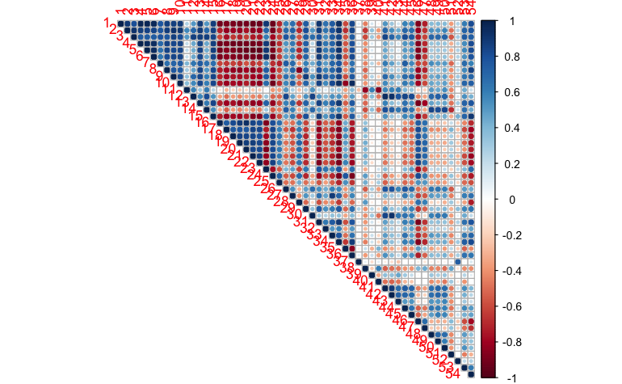

Now, we can go back to the documentation of the data and see that the primary components here are not the core metrics computed. There are three big dimensions: 1. Basic Human Needs 2. Foundations of Well-being 3. Opportunity

The SPI is an average of these three quantities which are again averages of four different quantities each. We remove this to have the core data to study.

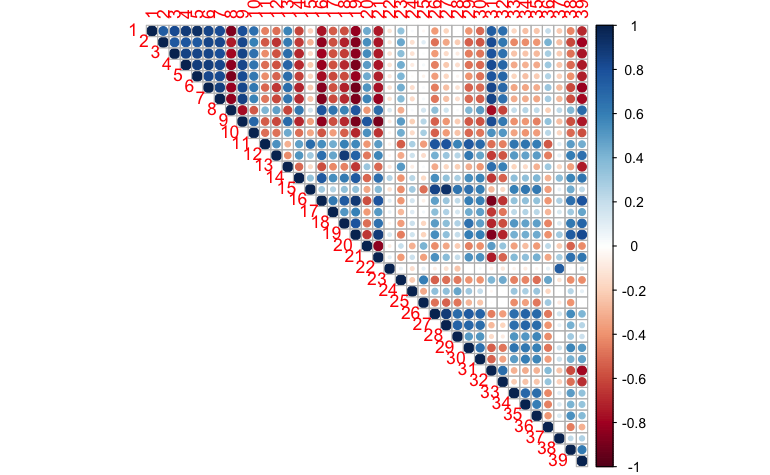

Now we conduct a PCA. What we observe is that the PC1 explains 50.0% PC2 explains 14.2% PC3 explains 4.6%  
PC4 explains 3.7%

```r
pve.core
```

```
 [1] 0.4995375309 0.1418431236 0.0458570024 0.0367125851 0.0324533884 0.0307786779
 [7] 0.0236679525 0.0192697154 0.0160904297 0.0149292014 0.0132099724 0.0127548837
[13] 0.0109588234 0.0100919687 0.0091445464 0.0084845289 0.0080622265 0.0076195313
[19] 0.0069743322 0.0057231996 0.0051095331 0.0045197027 0.0043852010 0.0037644713
[25] 0.0036404605 0.0035837786 0.0029618049 0.0028930647 0.0023884956 0.0021216353
[31] 0.0019817646 0.0018434924 0.0014749256 0.0012593072 0.0011036603 0.0009343887
[37] 0.0007930752 0.0006008931 0.0004767247
```

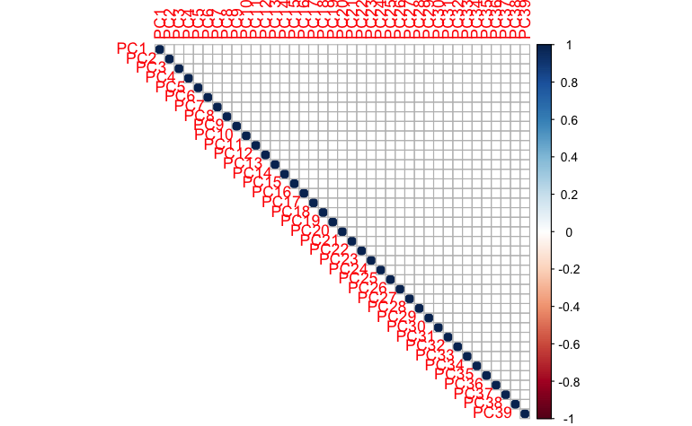

PC1: Foundations of well-being, health and wellness (+), … Basic human needs: lack of water and sanitation/shelter (-) PC2: Opportunity, lack of personal rights (-), … Foundations of well-being, environment quality (+) PC3: …

Now we do some plotting

```r
 fviz_pca_ind(pr.out.core, labelsize=3,
            col.ind = "contrib", # Color by the quality of representation
            axes=c(3,4),
            gradient.cols = c("#00AFBB", "#E7B800", "#FC4E07"),
            geom = c("point","text"),
            #select.ind = list(cos2 = 30),
            #theme(text = element_text(size = 2)),
            select.ind= list(name=c(topbotind3,topbotind4)),
            repel = TRUE     # Avoid text overlapping
            )
```

[output not shown]

Can we come up with a rank based on the PCAs. We can just use the first PCA. In general it is not suggested that we add scores from different PCAs … but if we still go ahead and do that for one more.

|  | Score | Rank AE | Rank SPI |
| --- | --- | --- | --- |
| Switzerland | 6.858366016 | 1 | 6 |
| Norway | 6.808963943 | 2 | 1 |
| Denmark | 6.758296779 | 3 | 2 |
| Sweden | 6.648665147 | 4 | 5 |
| Finland | 6.511241009 | 5 | 3 |
| Iceland | 6.417116916 | 6 | 9 |
| Luxembourg | 6.400102729 | 7 | 14 |
| Japan | 6.300462310 | 8 | 13 |
| Canada | 6.227915882 | 9 | 7 |
| Germany | 6.215779083 | 10 | 11 |

[output cut: 153 more lines]

###### End of PCA Analysis for Social Progress data.